# MPDW Pertemuan 5

Author

Yehezki Novandri Liman

Published

September 30, 2025

# Memuat Libraries

```r
library(ggplot2)
library(tseries)
library(MASS)
library(readxl)
```

# Input Data

```r
data <- read_xlsx("C:\\Users\\Yehezki\\Downloads\\Page Loads.xlsx")
print(data)
```

```
# A tibble: 2,167 × 3
   Date                Page.Loads Day
   <dttm>                   <dbl> <chr>
 1 2014-09-14 00:00:00       2146 Sunday
 2 2014-09-15 00:00:00       3621 Monday
 3 2014-09-16 00:00:00       3698 Tuesday
 4 2014-09-17 00:00:00       3667 Wednesday
 5 2014-09-18 00:00:00       3316 Thursday
 6 2014-09-19 00:00:00       2815 Friday
 7 2014-09-20 00:00:00       1658 Saturday
 8 2014-09-21 00:00:00       2288 Sunday
 9 2014-09-22 00:00:00       3638 Monday
10 2014-09-23 00:00:00       4462 Tuesday
# ℹ 2,157 more rows
```

Data yang diambil merupakan data frekuensi yang menunjukkan berapa banyak suatu website dikunjungi atau dimuat di laman internet dalam jangka waktu harian.

## Mengambil Data pada Baris ke-101 Sampai 200

```r
df <- data[101:200,]
print(df)
```

```
# A tibble: 100 × 3
   Date                Page.Loads Day
   <dttm>                   <dbl> <chr>
 1 2014-12-23 00:00:00       2298 Tuesday
 2 2014-12-24 00:00:00       1430 Wednesday
 3 2014-12-25 00:00:00       1002 Thursday
 4 2014-12-26 00:00:00       1486 Friday
 5 2014-12-27 00:00:00       1345 Saturday
 6 2014-12-28 00:00:00       1453 Sunday
 7 2014-12-29 00:00:00       2173 Monday
 8 2014-12-30 00:00:00       2208 Tuesday
 9 2014-12-31 00:00:00       1381 Wednesday
10 2015-01-01 00:00:00       1265 Thursday
# ℹ 90 more rows
```

## Eksplorasi Pola Data

```r
summary(df$Page.Loads)
```

```
   Min. 1st Qu.  Median    Mean 3rd Qu.    Max.
   1002    2768    3850    3790    5030    5884
```

### Barplot per Hari - Pola Mingguan

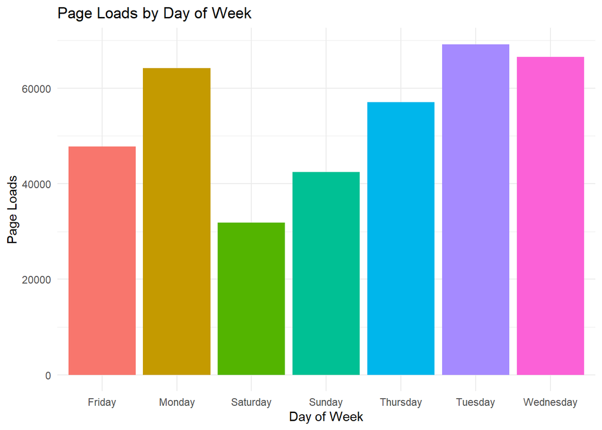

```r
ggplot(df, aes(x = Day, y = Page.Loads, fill = Day)) +
  geom_bar(stat = "identity") +
  labs(title = "Page Loads by Day of Week",
       x = "Day of Week", y = "Page Loads") +
  theme_minimal() +
  theme(legend.position = "none")
```

Visualisasi ini menunjukkan bahwa website ini lebih sering dikunjungi pada hari senin, selasa, rabu dan kamis dalam jangka waktu Desember 2014 - April 2015. Hal ini diindikasikan dengan jumlah page loads lebih dari 50.000 pada masing-masing hari tersebut. Hari selasa merupakan hari dengan total angka kunjungan website tertinggi, sedangkan hari sabtu merupakan hari dengan total angka kunjungan website terendah.

### Boxplot Per Hari

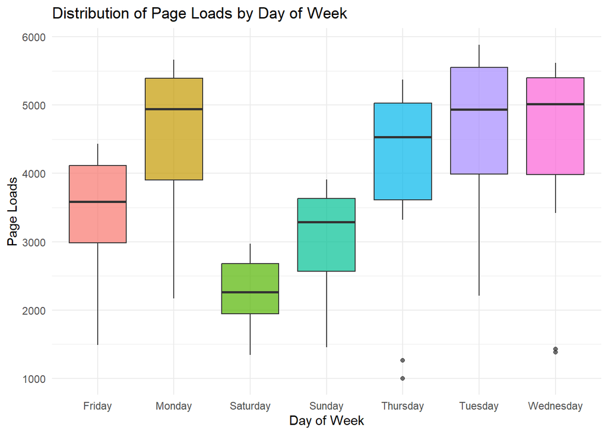

```r
ggplot(df, aes(x = Day, y = Page.Loads, fill = Day)) +
  geom_boxplot(alpha = 0.7) +
  labs(title = "Distribution of Page Loads by Day of Week",
       x = "Day of Week", y = "Page Loads") +
  theme_minimal() +
  theme(legend.position = "none")
```

Visualisasi Boxplot per hari ini menunjukkan sebaran dari masing-masing hari terhadap kunjugan website harian. Terlihat bahwa hari rabu memiliki median tertinggi page loads website dibanding hari lainnya, sedangkan hari sabtu memiliki median terendah. Terlihat pola yang sama seperti yang ditampilkan pada barplot, dimana hari senin, selasa, rabu dan kamis merupakan hari-hari dimana website tersebut dominan dikunjungi oleh orang-orang.

### Line Plot / Time Series Plot

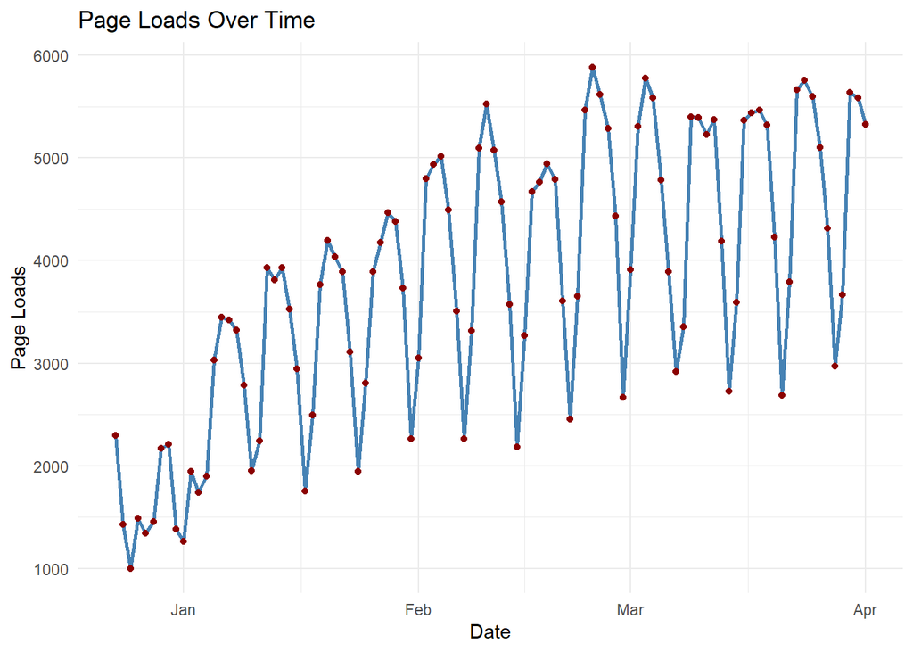

```r
ggplot(df, aes(x = Date, y = Page.Loads)) +
  geom_line(color = "steelblue", linewidth = 1) +
  geom_point(color = "darkred") +
  labs(title = "Page Loads Over Time",
       x = "Date", y = "Page Loads") +
  theme_minimal()
```

Melalui line plot atau time series plot, Terlihat bahwa data page loads memiliki tren meningkat dari bulan Desember 2014 hingga April 2015 dengan pola musiman dalam jarak mingguan.

## Mengubah Tipe Data Agar Terbaca Sebagai Data Deret Waktu

```r
df.ts <- ts(df$Page.Loads)
```

## Membuat Plot Time Series

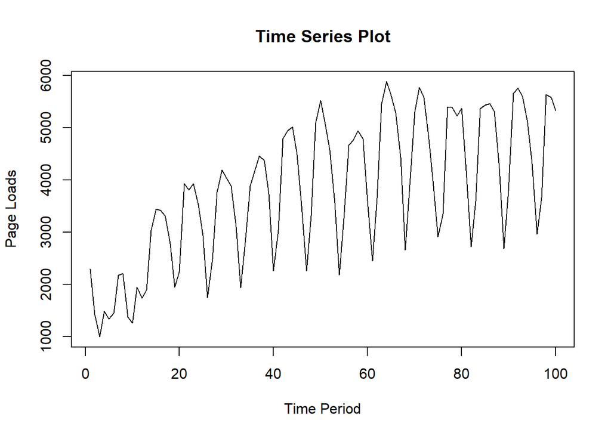

```r
plot(df.ts, type = "l",
     xlab="Time Period", ylab="Page Loads",
     main = "Time Series Plot")
```

Terlihat dengan jelas pada visualisasi plot time series tersebut bahwa data yang kita miliki tidak stasioner dalam rataan. Terdapat pola musiman dengan tren meningkat yang muncul dalam jangka waktu mingguan pada data tersebut. Namun, data ini terlihat stasioner dalam ragam. Hal ini dikarenakan lebar pita dalam plot time series cenderung sama. Selanjutnya, akan dilakukan pengecekan kestasioneran dengan uji formal ADF.

# Pengecekan Kestasioneran

## Plot ACF

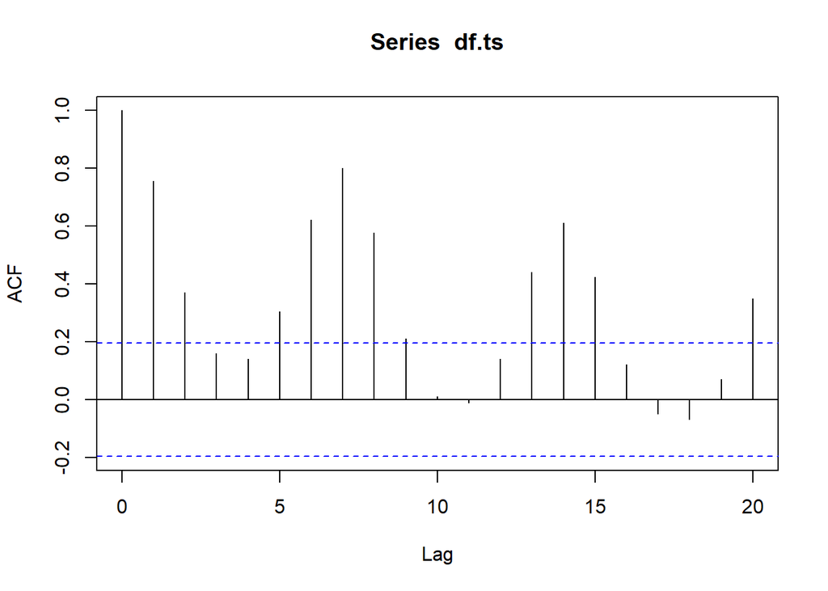

```r
acf(df.ts)
```

Pada plot ACF, terlihat bahwa autokorelasi menurun secara perlahan membentuk gelombang sinus pada banyak lag. Hal ini mengindikasikan adanya ketidakstasioneran dalam rataan.

## Uji ADF

$H_0$ : Data tidak stasioner dalam rataan

$H_1$ : Data stasioner dalam rataan

```r
tseries::adf.test(df.ts)
```

```
    Augmented Dickey-Fuller Test

data:  df.ts
Dickey-Fuller = -4.0055, Lag order = 4, p-value = 0.01177
alternative hypothesis: stationary
```

Berdasarkan uji ADF tersebut, didapat *p-value* lebih kecil dari taraf nyata 5% sehingga tolak $H_0$ dan menandakan bahwa **data stasioner dalam rataan**. Hal ini tidak sejalan dengan eksplorasi ACF maupun plot time series. Tapi, kita akan mengikuti hasil dari uji formal ADF. Sehingga, data ini stasioner dalam rataan.

## Plot Box-Cox

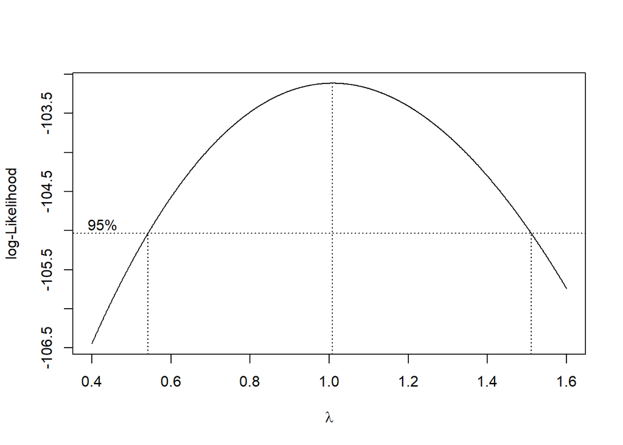

```r
index <- seq(1, 100)

bc <- boxcox(
  df.ts ~ index,
  lambda = seq(0.4, 1.6, by = 0.001)
)
```

```r
lambda <- bc$x[which.max(bc$y)]
lambda
```

```
[1] 1.008
```

```r
ci_lambda <- bc$x[bc$y > max(bc$y) - 0.5 * qchisq(0.95, 1)]

ci_lower <- min(ci_lambda)
ci_upper <- max(ci_lambda)

c(Batas_Bawah = ci_lower, Batas_Atas = ci_upper)
```

```
Batas_Bawah  Batas_Atas
      0.542       1.511
```

Gambar di atas menunjukkan nilai λ optimum (rounded value) sebesar **1,008** dan selang kepercayaan 95% nilai memiliki batas bawah **0,542** dan batas atas **1,511**. Selang tersebut memuat nilai satu sehingga dapat dikatakan bahwa data ini **stasioner dalam ragam**.